# HW3

Nikhil Gopal

10/25/2021

```r
rm(list = ls())
library(raster)
library(glmnet)
library(dplyr)
setwd("G:/My Drive/STAT 3105/HW3/")
```

**1a Does one/none/both of the cost functions encourage sparse estimates? If so, which one? Explain your answer.**

The q = 0.5 cost function encourages sparce estimates. Relative to the other function, this function provides $l_i$ that are closer to the origin on average. From looking at the constraint regions for the parameters, we know that the 0.5 function would encourage sparce estimates.

**1b Which of the points x1, . . . , x5 would achieve the smallest cost under the `q-constrained least squares cost function? For each of the two cases, name the respective point and give a brief explanation for your answer.**

For q = 0.5, beta becomes zero when the line intersects the beta1 axis, which occurs at point x3.

For q = 4, beta becomes zero when the line intersects the ellipse, which occurs at point x4.

**1c Write down the loss function with q = 0.5 and q = 4 respectively. Which one do you think is easier to solve numerically and why?**

Loss q = 4:

$$\mathcal{L}_{\lambda, 4} = \sum_{i = 1}^n (y_i - \sum_{j = 1}^2 x_j\beta_j)^2 + \lambda (\sum_{i = 1}^2 |\beta_i|^{4})^{\frac{1}{4}}$$
Loss q = 0.5:

$$\mathcal{L}_{\lambda, 0.5} = \sum_{i = 1}^n (y_i - \sum_{j = 1}^2 x_j\beta_j)^2 + \lambda (\sum_{i = 1}^2 |\beta_i|^{0.5})^{\frac{1}{0.5}}$$

The convex function (q = 4) would be easier to solve. As shown on the diagrams in the lecture, local minimums are global minimums for convex functions, whereas with nonconvex functions, one cannot be sure that a local minimum is a global minimum. Thus, finding one local minimum is sufficient to solve a convex loss function, making it easier to solve overall.

**2a Using the 5 penalty values of λ mentioned above to fit the ridge regression model. You will have the coefficient β ∈ R16384. Reshape β into 128 × 128 matrix, and plot the matrix as in the original image. Which coefficient yields the best result?**

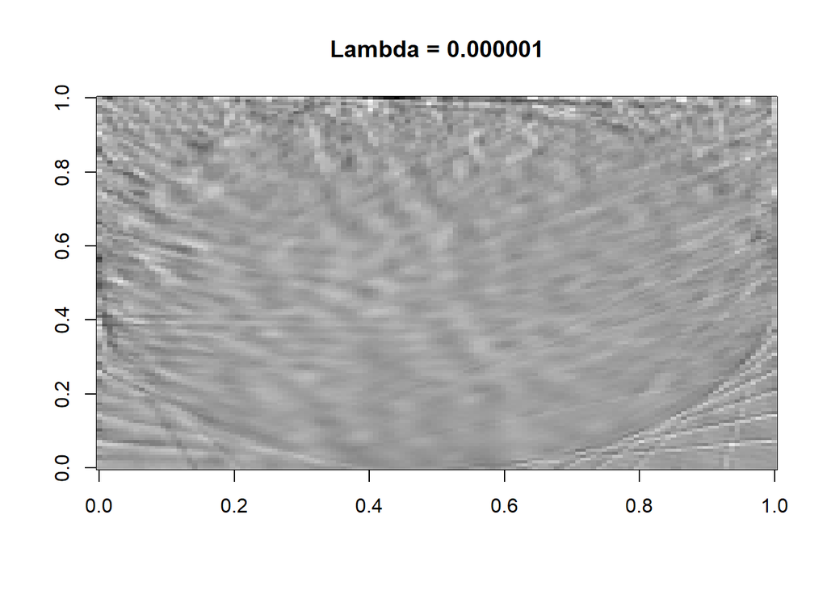

```r
X_mat <- as.matrix(read.table(file = "hw3_Q2_X.txt"))

Y_lst <- as.matrix(read.table("hw3_Q2_Y.txt"))

# Ridge Regression (alpha = 0)
ridge_reg1 <- glmnet(X_mat, Y_lst, family = "gaussian", intercept = T,
alpha=0, lambda = 0.000001, lambda.min.ratio = 1e-8,
standardize = F, nlambda = 1)

ridge_reg2 <- glmnet(X_mat, Y_lst, family = "gaussian", intercept = T,
alpha=0, lambda = 0.0001, lambda.min.ratio = 1e-8,
standardize = F, nlambda = 1)

ridge_reg3 <- glmnet(X_mat, Y_lst, family = "gaussian", intercept = T,
alpha=0, lambda = 0.01, lambda.min.ratio = 1e-8,
standardize = F, nlambda = 1)

ridge_reg4 <- glmnet(X_mat, Y_lst, family = "gaussian", intercept = T,
alpha=0, lambda = 0.1, lambda.min.ratio = 1e-8,
standardize = F, nlambda = 1)

ridge_reg5 <- glmnet(X_mat, Y_lst, family = "gaussian", intercept = T,
alpha=0, lambda = 1, lambda.min.ratio = 1e-8,
standardize = F, nlambda = 1)

# Reshape Ridge Coefficients to a 128x128 matrix
beta_mat6 <- matrix(ridge_reg1$beta[,1], nrow=128, byrow=T)
beta_mat7 <- matrix(ridge_reg2$beta[,1], nrow=128, byrow=T)
beta_mat8 <- matrix(ridge_reg3$beta[,1], nrow=128, byrow=T)
beta_mat9 <- matrix(ridge_reg4$beta[,1], nrow=128, byrow=T)
beta_mat10 <- matrix(ridge_reg5$beta[,1], nrow=128, byrow=T)

# Visualize the Matrix in Grey Scale
image(t(apply(beta_mat6, 2, rev)), col=grey(seq(0, 1, length=256)), main = "Lambda = 0.000001")
```

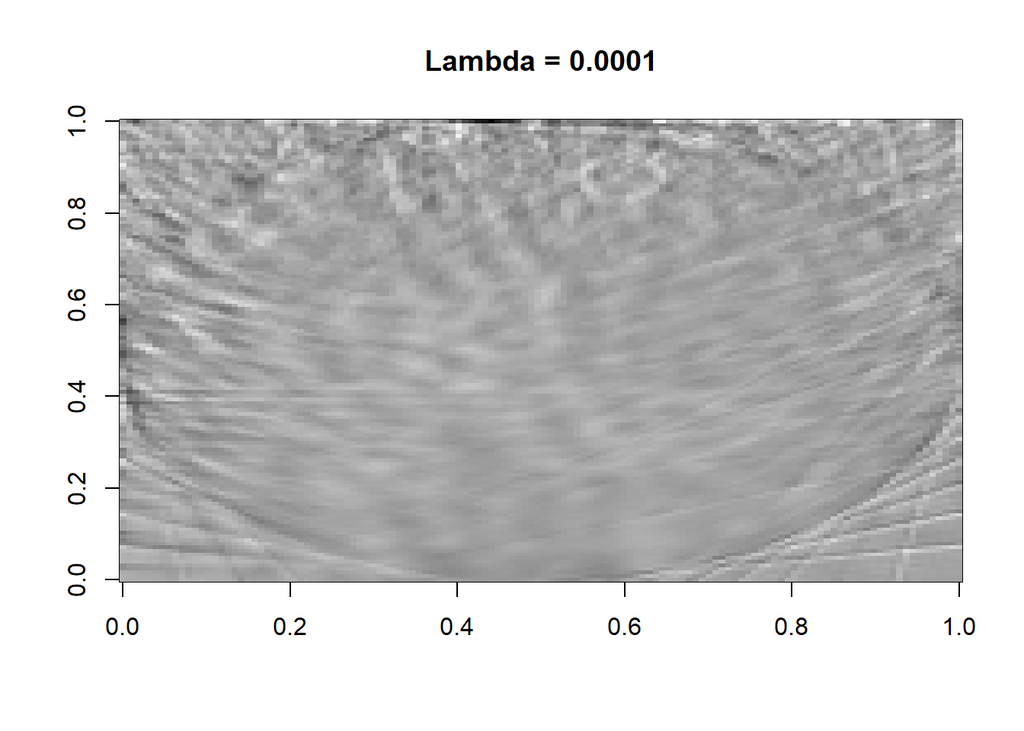

```r
image(t(apply(beta_mat7, 2, rev)), col=grey(seq(0, 1, length=256)), main = "Lambda = 0.0001")
```

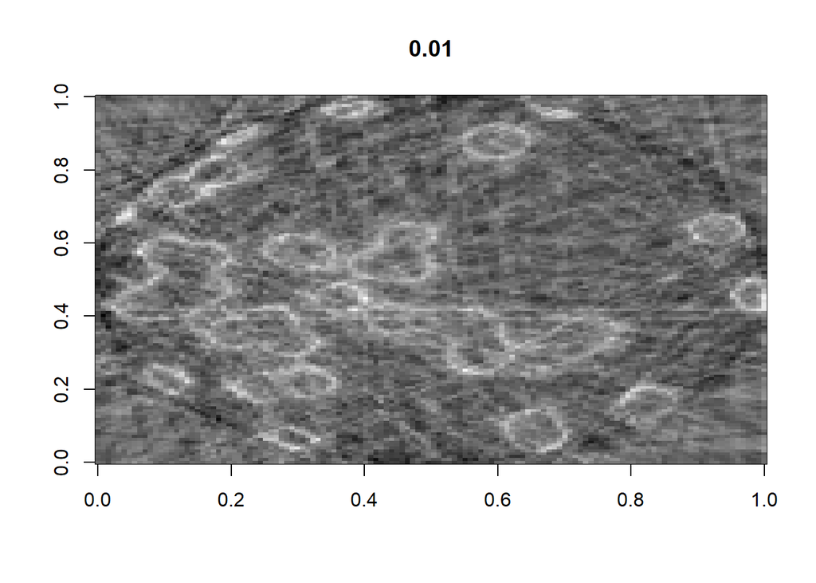

```r
image(t(apply(beta_mat8, 2, rev)), col=grey(seq(0, 1, length=256)), main = "0.01")
```

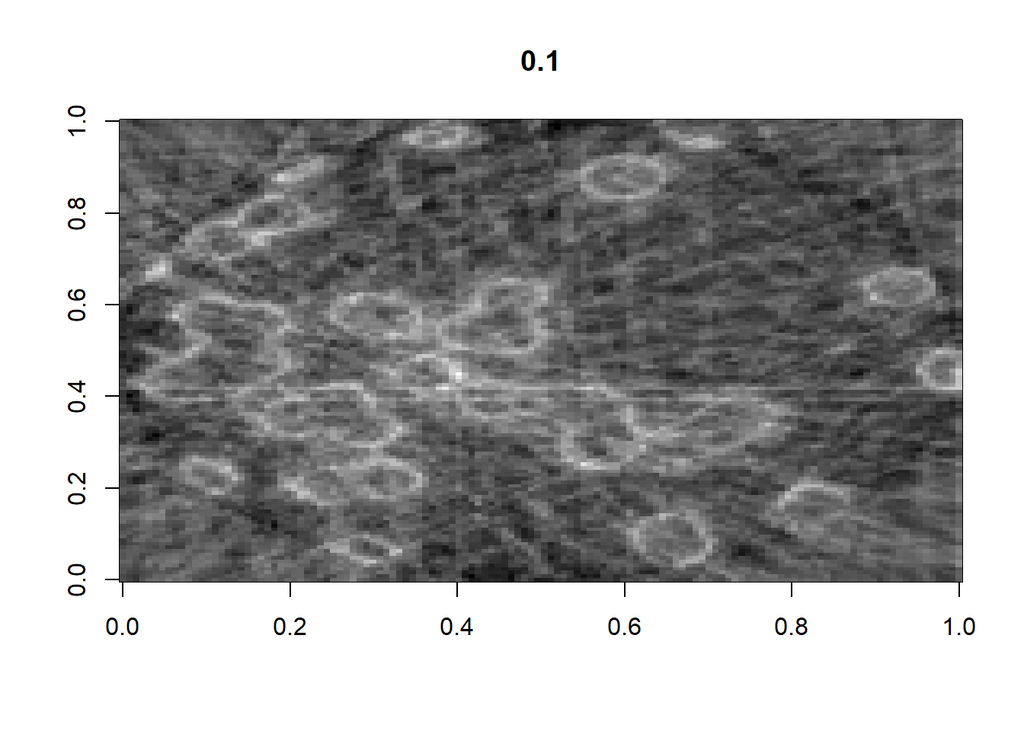

```r
image(t(apply(beta_mat9, 2, rev)), col=grey(seq(0, 1, length=256)), main = "0.1")
```

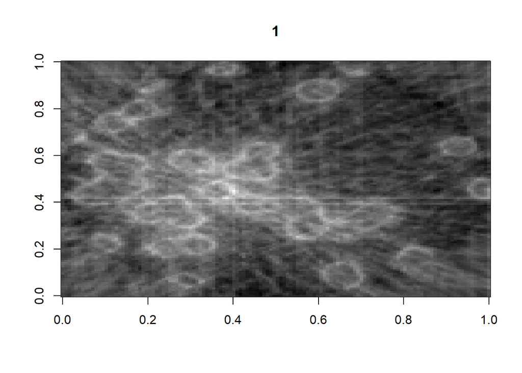

```r
image(t(apply(beta_mat10, 2, rev)), col=grey(seq(0, 1, length=256)), main = "1")
```

The ridge model with lambda = 0.1 yielded the best results.

**2b Using the 5 penalty values of λ mentioned above to fit the lasso model. You will have the coefficient β ∈ R 16384. Reshape β into 128 × 128 matrix, and plot the matrix as in the original image. Which coefficient yields the best result?**

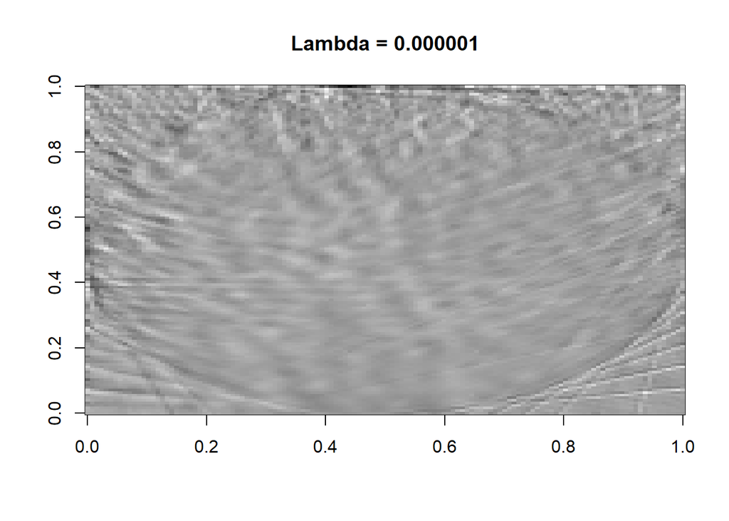

```r
#import data



# Lasso Regression (alpha = 1)
lasso_reg1 <- glmnet(X_mat, Y_lst, family = "gaussian", intercept = T,
alpha=1, lambda = 0.000001, lambda.min.ratio = 1e-8,
standardize = F, nlambda = 1)

lasso_reg2 <- glmnet(X_mat, Y_lst, family = "gaussian", intercept = T,
alpha=1, lambda = 0.0001, lambda.min.ratio = 1e-8,
standardize = F, nlambda = 1)

lasso_reg3 <- glmnet(X_mat, Y_lst, family = "gaussian", intercept = T,
alpha=1, lambda = 0.01, lambda.min.ratio = 1e-8,
standardize = F, nlambda = 1)

lasso_reg4 <- glmnet(X_mat, Y_lst, family = "gaussian", intercept = T,
alpha=1, lambda = 0.1, lambda.min.ratio = 1e-8,
standardize = F, nlambda = 1)

lasso_reg5 <- glmnet(X_mat, Y_lst, family = "gaussian", intercept = T,
alpha=1, lambda = 1, lambda.min.ratio = 1e-8,
standardize = F, nlambda = 1)


# Reshape Lasso Coefficients to a 128x128 matrix
beta_mat1 <- matrix(lasso_reg1$beta[,1], nrow=128, byrow=T)
beta_mat2 <- matrix(lasso_reg2$beta[,1], nrow=128, byrow=T)
beta_mat3 <- matrix(lasso_reg3$beta[,1], nrow=128, byrow=T)
beta_mat4 <- matrix(lasso_reg4$beta[,1], nrow=128, byrow=T)
beta_mat5 <- matrix(lasso_reg5$beta[,1], nrow=128, byrow=T)


# Visualize the Matrix in Grey Scale
image(t(apply(beta_mat1, 2, rev)), col=grey(seq(0, 1, length=256)), main = "Lambda = 0.000001")
```

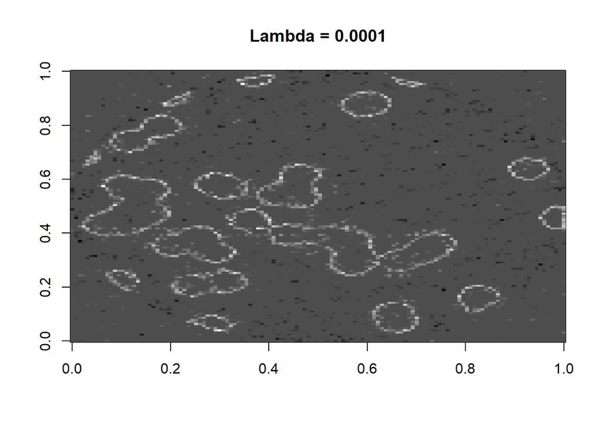

```r
image(t(apply(beta_mat2, 2, rev)), col=grey(seq(0, 1, length=256)), main = "Lambda = 0.0001")
```

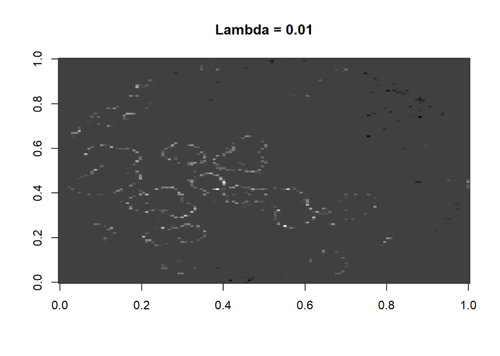

```r
image(t(apply(beta_mat3, 2, rev)), col=grey(seq(0, 1, length=256)), main = "Lambda = 0.01")
```

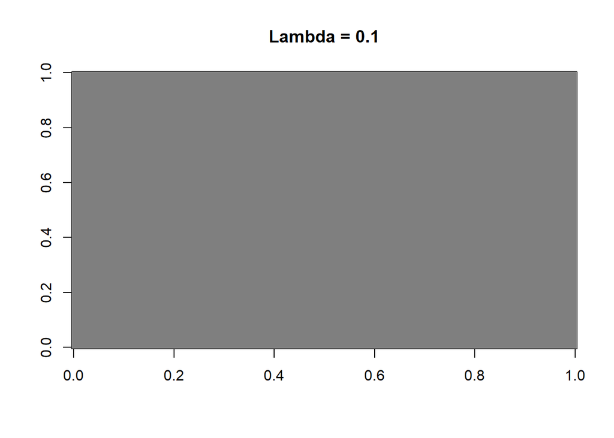

```r
image(t(apply(beta_mat4, 2, rev)), col=grey(seq(0, 1, length=256)), main = "Lambda = 0.1")
```

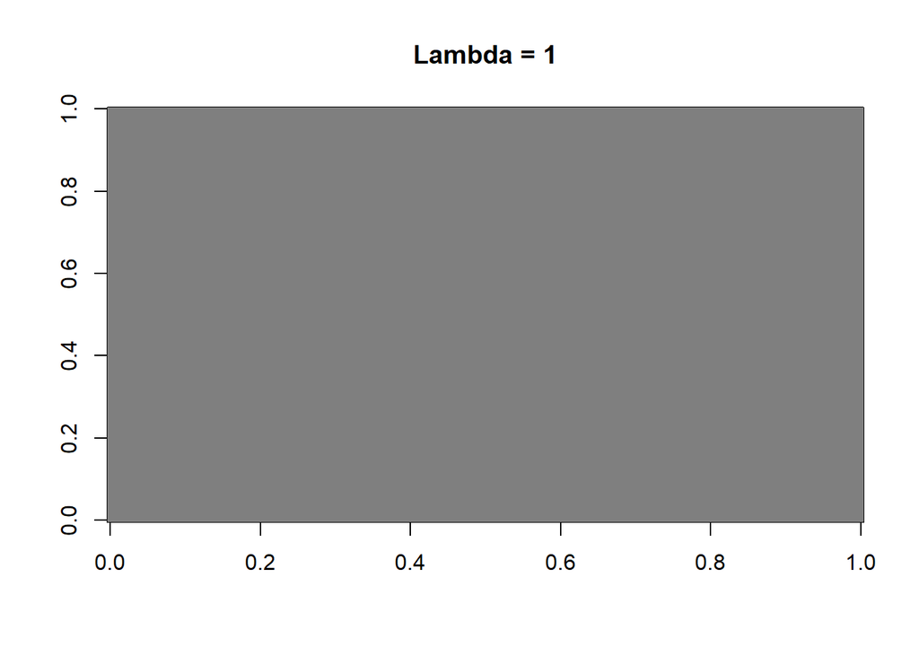

```r
image(t(apply(beta_mat5, 2, rev)), col=grey(seq(0, 1, length=256)), main = "Lambda = 1")
```

The Lasso model with Lambda = 0.0001 yielded the best result.

**2c Comparing the best results from lasso and ridge regression respectively, what do you find?**

We notice that the lasso model was able to provide a better image than the ridge model, as the picture is more clear and has less noise. The individual cirlces are clearer compared to the background in the lasso photo. Lasso regression tends to make a lot of coefficients equal to zero, which is useful in situations like this that have lots of noise. This is why in the lasso photo, we do not see as many lines compared to the ridge photo, resulting in a clearer image.

**Project Question Series 2**

**1. Use the methods discussed in HW session 2 to clean the data. Make sure you are using the cleaned data for all subsequent problems.**

```r
flights_data <- read.csv("pnwflights14.csv")

# Remove NAs
flights_data <- na.omit(flights_data)

# Remove nonsense entries
flights_data <- flights_data[-which(flights_data$dep_time < 0),]
flights_data <- flights_data[-which(flights_data$air_time < 0),]
flights_data <- flights_data[-which(flights_data$distance < 0),]
```

**2. Set X = (dep_time, dep_delay, arr_time) as the predictors and Y = arr_delay as the response variable, formulate a linear regression model to help your instructor to predict the travel time of future trips.**

```r
flights_lm <- lm(arr_delay ~ dep_time + dep_delay + arr_time, data = flights_data)
summary(flights_lm)
```

```
##
## Call:
## lm(formula = arr_delay ~ dep_time + dep_delay + arr_time, data = flights_data)
##
## Residuals:
##     Min      1Q  Median      3Q     Max
## -61.143  -7.190  -0.357   6.509 151.813
##
## Coefficients:
##               Estimate Std. Error t value Pr(>|t|)
## (Intercept) -4.609e+00  1.036e-01  -44.51   <2e-16 ***
## dep_time    -1.115e-03  6.660e-05  -16.74   <2e-16 ***
## dep_delay    9.910e-01  1.085e-03  913.41   <2e-16 ***
## arr_time     1.494e-03  6.597e-05   22.64   <2e-16 ***
## ---
## Signif. codes:  0 '***' 0.001 '**' 0.01 '*' 0.05 '.' 0.1 ' ' 1
##
## Residual standard error: 11.95 on 145455 degrees of freedom
## Multiple R-squared:  0.8535, Adjusted R-squared:  0.8535
## F-statistic: 2.824e+05 on 3 and 145455 DF,  p-value: < 2.2e-16
```

**3. Apply the regression analysis to get parameter estimation for your proposed models and translate the Y = Xβ equation into plain English so that your instructor can tell her grandma.**

$$ArrDelay = -1.115e^{-3}DepTime + 9.910e^{-1}DepDelay + 1.494e^{-3}ArrTime -4.609e$$

**4. Validate the assumptions behind the linear regression model or diagnose the residuals.**

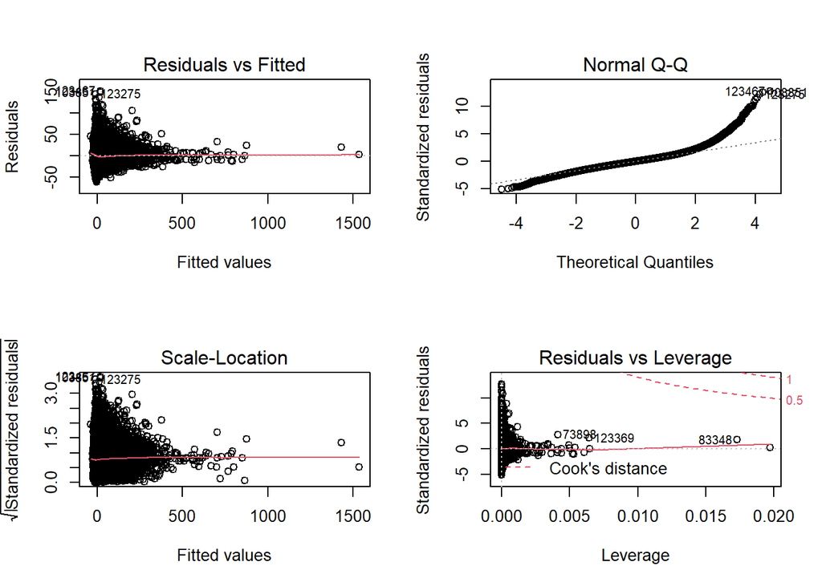

```r
par(mfrow = c(2, 2))
plot(flights_lm)
```

Linearity:

We are able to verify the linearity assumption by looking at the residuals vs the fitted data plot. We see a horizontal red line and thus no pattern between the residuals and the fitted values, indicating a high likelihood of a linear relationship between the predictors and the response variable.

Constant Variance:

We are able to verify the constant varaince assumption by looking at the scale location plot. Again, we see a horizontal red line indicating that the residuals are spread equally among ranges of predictors, demonstrating constant variance.

High Leverage:

Outliers:

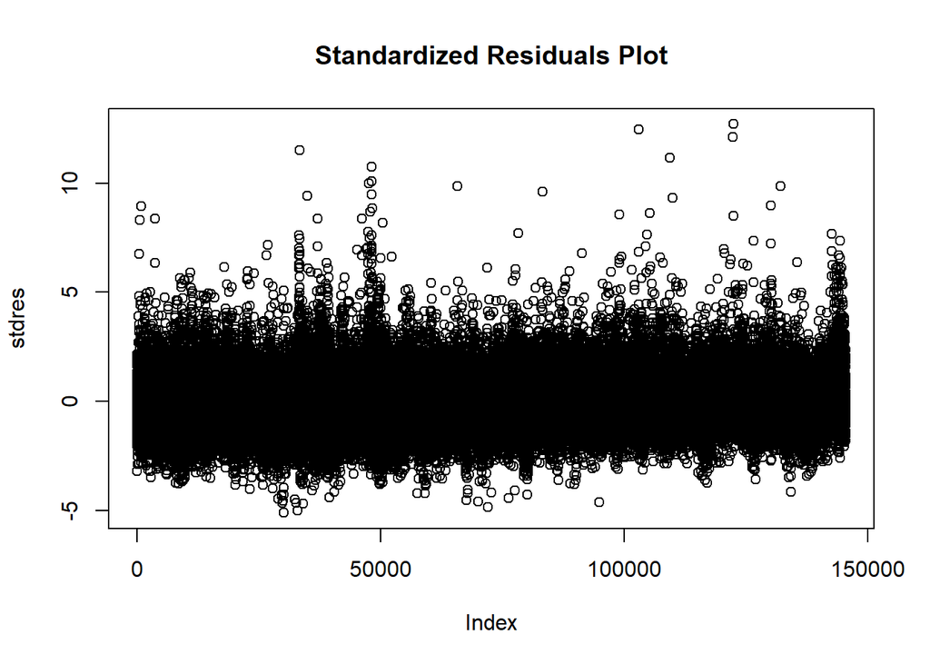

```r
stdres = rstandard(flights_lm)
plot(stdres, main = "Standardized Residuals Plot")
```

From the standardized residual plot, we observe that there are many values with standardized residuals > 3 or < -3. Thus, we can confirm that there are outliers in this data and these should be dealt with to meet the assumptions of regression.

Influential points:

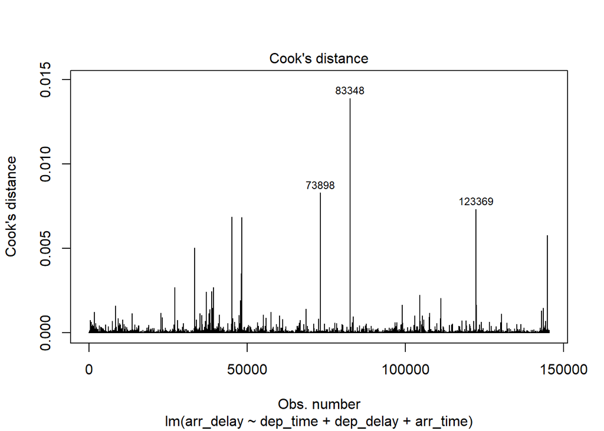

```r
plot(flights_lm, 4)
```

**5. Try to include more information and formulate another linear regression model.**

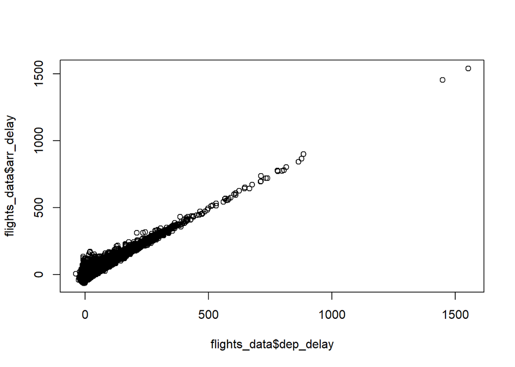

```r
plot(x = flights_data$dep_delay, y = flights_data$arr_delay)
```

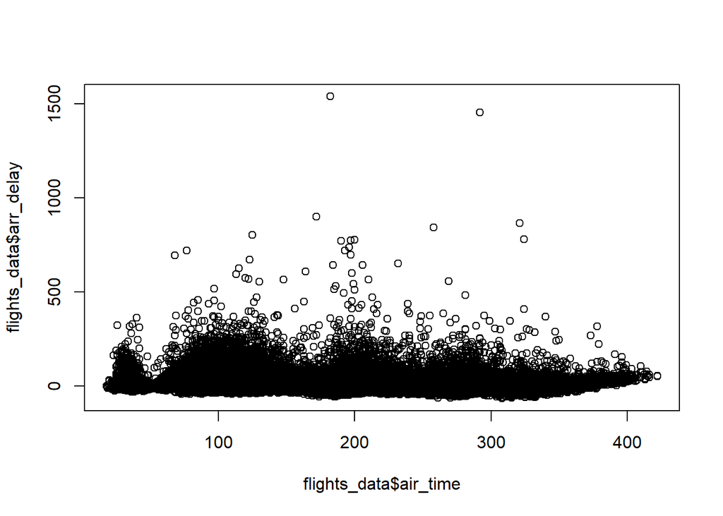

```r
plot(x = flights_data$air_time, y = flights_data$arr_delay)
```

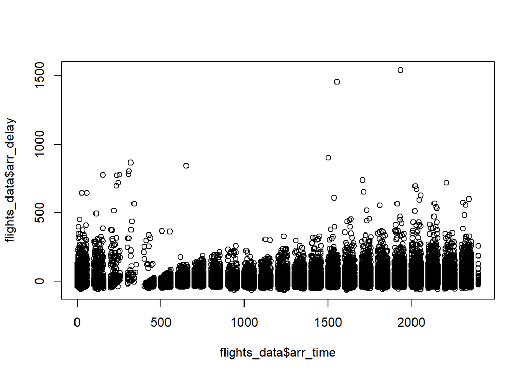

```r
plot(x = flights_data$arr_time, y = flights_data$arr_delay)
```

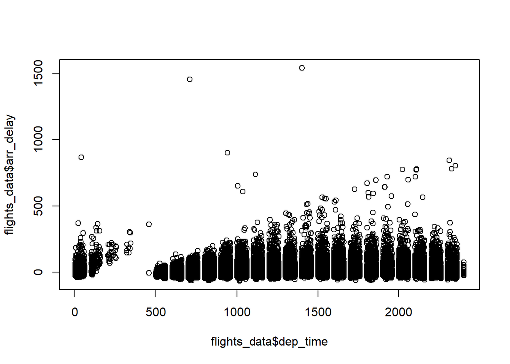

```r
plot(x = flights_data$dep_time, y = flights_data$arr_delay)
```

```r
#Explain in the solution
improved_model <- lm(arr_delay ~ dep_delay + origin + dest + year + month, data = flights_data)

#detect collinearity in the variables
library(mctest)
omcdiag(flights_lm)
```

```
##
## Call:
## omcdiag(mod = flights_lm)
##
##
## Overall Multicollinearity Diagnostics
##
##                        MC Results detection
## Determinant |X'X|:         0.8079         0
## Farrar Chi-Square:     31032.8812         1
## Red Indicator:             0.2571         0
## Sum of Lambda Inverse:     3.4681         0
## Theil's Method:           -1.3223         0
## Condition Number:          7.1708         0
##
## 1 --> COLLINEARITY is detected by the test
## 0 --> COLLINEARITY is not detected by the test
```

```r
imcdiag(flights_lm)
```

```
##
## Call:
## imcdiag(mod = flights_lm)
##
##
## All Individual Multicollinearity Diagnostics Result
##
##              VIF    TOL        Wi        Fi Leamer   CVIF Klein IND1   IND2
## dep_time  1.2339 0.8104 17010.893 34022.020 0.9002 1.3907     0    0 1.4784
## dep_delay 1.0169 0.9834  1226.476  2452.969 0.9917 1.1461     0    0 0.1293
## arr_time  1.2173 0.8215 15803.301 31606.819 0.9064 1.3720     0    0 1.3922
##
## 1 --> COLLINEARITY is detected by the test
## 0 --> COLLINEARITY is not detected by the test
##
## * all coefficients have significant t-ratios
##
## R-square of y on all x: 0.8535
##
## * use method argument to check which regressors may be the reason of collinearity
## ===================================
```

```r
#split into test/train
split <- sort(sample(nrow(flights_data), nrow(flights_data)*0.7))
train <- flights_data[split,]
test <- flights_data[-split,]


library(caret)
#to get same results each time
set.seed(3456)


trainIndex <- createDataPartition(flights_data$arr_delay, p = .7,
                                  list = FALSE,
                                  times = 1)
Train <- flights_data[trainIndex,]
Valid <- flights_data[-trainIndex,]

#run the CV
CVmodel <- train(
  arr_delay ~ dep_delay + origin + dest + year + month, data = Train,
  method = "lm",
  trControl = trainControl(
    method = "cv", number = 10
  )
)
#calculate RMSE
RMSE_Modelcv <- CVmodel$results$RMSE

#Calculate RMSE of original model
p <- predict(flights_lm, Valid)
error <- (p- Valid$arr_time)
RMSE_Model <- sqrt(mean(error^2))

#Calculate RMSE of improved model no CV
p <- predict(improved_model, Valid)
error <- (p- Valid$arr_time)
RMSE_Model2 <- sqrt(mean(error^2))
```

**6. Which model is the best among your analysis, and give the reason for your choice.**

```r
summary(CVmodel)
```

```
##
## Call:
## lm(formula = .outcome ~ ., data = dat)
##
## Residuals:
##     Min      1Q  Median      3Q     Max
## -59.084  -7.097  -0.757   6.008 156.334
##
## Coefficients: (1 not defined because of singularities)
##               Estimate Std. Error t value Pr(>|t|)
## (Intercept)  -7.863669   0.494578 -15.900  < 2e-16 ***
## dep_delay     0.991170   0.001279 774.769  < 2e-16 ***
## originSEA     0.607776   0.082724   7.347 2.04e-13 ***
## destANC      -0.630412   0.515467  -1.223 0.221336
## destATL      -0.855764   0.537005  -1.594 0.111032
## destAUS       1.684429   0.863631   1.950 0.051131 .
## destBLI      11.735388   1.583853   7.409 1.28e-13 ***
## destBNA      -6.357268   1.281014  -4.963 6.96e-07 ***
## destBOI       3.230851   1.596825   2.023 0.043045 *
## destBOS       1.274017   0.580838   2.193 0.028280 *
## destBUR       5.345110   0.583040   9.168  < 2e-16 ***
## destBWI       0.321749   0.874941   0.368 0.713069
## destBZN      -3.214869  11.685444  -0.275 0.783227
## destCLE       9.173414   2.298778   3.991 6.60e-05 ***
## destCLT       1.179812   0.647202   1.823 0.068315 .
## destCOS       3.652211   0.910144   4.013 6.01e-05 ***
## destCVG      -0.555034   1.269897  -0.437 0.662061
## destDCA       2.068017   0.657402   3.146 0.001657 **
## destDEN       2.555599   0.507859   5.032 4.86e-07 ***
## destDFW       1.020486   0.522450   1.953 0.050790 .
## destDTW      -0.025523   0.592038  -0.043 0.965613
## destEUG       7.926364   0.762070  10.401  < 2e-16 ***
## destEWR      -2.871546   0.579804  -4.953 7.33e-07 ***
## destFAI      -1.718468   0.639979  -2.685 0.007250 **
## destFAT       5.498691   0.719678   7.640 2.18e-14 ***
## destFLL       5.114399   0.900526   5.679 1.36e-08 ***
## destGEG       6.184583   0.597433  10.352  < 2e-16 ***
## destHDN       2.235076   2.432333   0.919 0.358149
## destHNL       1.550626   0.576249   2.691 0.007127 **
## destHOU       4.181735   1.147546   3.644 0.000268 ***
```

[output cut: 36 more lines]

```
## destSJC       5.844609   0.518826  11.265  < 2e-16 ***
## destSLC       2.118944   0.521080   4.066 4.78e-05 ***
## destSMF       4.755801   0.528381   9.001  < 2e-16 ***
## destSNA       6.535483   0.546439  11.960  < 2e-16 ***
## destSTL       3.022018   0.816627   3.701 0.000215 ***
## destTPA     -20.012423   1.155625 -17.317  < 2e-16 ***
## destTUS      -0.129823   0.730498  -0.178 0.858944
## year                NA         NA      NA       NA
## month         0.120356   0.011128  10.816  < 2e-16 ***
## ---
## Signif. codes:  0 '***' 0.001 '**' 0.01 '*' 0.05 '.' 0.1 ' ' 1
##
## Residual standard error: 11.68 on 101749 degrees of freedom
## Multiple R-squared:  0.8575, Adjusted R-squared:  0.8574
## F-statistic:  8385 on 73 and 101749 DF,  p-value: < 2.2e-16
```